# Visualización de resultados

# Introducción

En esta libreta de ejercicios prácticos, aprenderás a:

- Producir *‘linear plots’* usando los resultados de algunos de los ejercicios de la práctica anterior.
- Seguir la documentación del paquete `ckbplotr` para hacer linear plots más elaborados y *forest plots*.

## Agradecimientos

Los ejemplos mostrados aquí están en gran medida extraídos de la documentación del paquete de R `ckbplotr()`, desarrollado por [Neil Wright](https://www.ndph.ox.ac.uk/team/neil-wright) del China Kadoorie Biobank.

# Flujo de trabajo para graficar

Graficar resultados generalmente sigue los siguientes pasos:

1. Hacer el análisis
2. Extraer los números necesarios para graficar
3. Calcular números adicionales donde sea necesario
4. Construir un data frame
5. Hacer un gráfico básico
6. Editar el gráfico según se requiera

# Preparación

Para esta práctica, se recomienda que comiences un nuevo script de R y una nueva sesión de R (es decir, empezar con un entorno global vacío).

## Crear script de R

Abre el proyecto de R creado en el material previo al curso (es decir, `workshop.Rproj`).

Ve a **File** > **New File** > **R Script**

En el script **Untitled1** que acabas de crear, escribe:

```r
# Práctica 2
# Autor: tu nombre va aquí
# Última edición: 09/Oct/2025
```

Ahora, guardemos el script:

- Ve a **File** > **Save As…** (nota que RStudio automáticamente abre en la ubicación del proyecto de R). Guarda el archivo de script en el directorio raíz del proyecto.
- Guarda este script como `02.practico-2.R`.

## Cargar datos

Cargaré el conjunto de datos `mcps-like.csv` y limpiaré los nombres de las columnas de una vez.

```r
# Cargar el paquete data.table, instalado en el material previo al curso
pacman::p_load(data.table,tidyverse)

# Cargar los datos simulados 'mcps-like.csv'
dummy_df <-
  data.table::fread(file = 'data/mcps-like.csv') %>%
  # limpiar nombres
  janitor::clean_names()
```

Ahora, hagamos rápidamente todos los pasos de limpieza de datos en los que trabajamos durante la práctica 1.

**Pista:** ¡está bien copiar y pegar!

```r
# Hacer una nueva variable de sexo como factor
dummy_df$sex <- factor(ifelse(dummy_df$male == 1, "Hombres", "Mujeres"))

# Nombrar la nueva variable
dummy_df$new_diabetes <-
  # Devuelve un vector con el valor máximo de los vectores de entrada
  pmax(dummy_df$base_diabetes,
       dummy_df$drug_antidiabetic,
       # valores faltantes son removidos
       na.rm = TRUE)

# Hacer las bandas de edad de 10 años
dummy_df$age_10yr <- cut(dummy_df$age-0.5,
                         breaks = c(34, 44, 54, 64, 74, 84),
                         labels = c("35-44", "45-54", "55-64", "65-74", "75-84"),
                         right = TRUE,
                         include.lowest = TRUE)

dummy_df$edu_level_cat <-
  factor(dummy_df$edu_level,
         levels = c(1, 2, 3, 4),
         labels = c("Universidad/Colegio", "Preparatoria", "Primaria", "Otro"))

dummy_df$smokegp_cat <-
  factor(dummy_df$smokegp,
         levels = c(1, 2, 3, 4, 5),
         labels = c("Nunca", "Ex-fumador", "<Diario", "Diario <10/d", "Diario 10+/d"))

dummy_df$alcgp_cat <-
  factor(dummy_df$alcgp,
         levels = c(1, 2, 3, 4, 5),
         labels = c("Nunca", "Ex-bebedor", "Hasta 3 veces/mes", "Hasta 2 veces/sem", "3+ veces/sem"))

dummy_df$physgp_cat <-
  factor(dummy_df$physgp,
         levels = c(1, 2, 3),
         labels = c("Ninguna", "Hasta 2 veces/sem", "3+ veces/sem"))
```

# 1. Crear un ‘linear plot’

Hagamos un gráfico de forma mostrando la asociación entre tabaquismo y mortalidad vascular de la práctica 1.

## Realiza el análisis

Primero, repitamos los análisis.

```r
pacman::p_load(survival)
smk_cox_mod<-
  # Definir modelo usando la función coxph
  coxph(
    # El lado izquierdo de la ecuación incluye el seguimiento y la censura
    Surv(person_years,d015) ~
      # El lado derecho incluye todos los factores de interés
      smokegp_cat + age_10yr + sex + coyoacan + edu_level_cat +  alcgp_cat + physgp_cat,
      # Los datos a usar
      data = dummy_df)
```

## Extraer los números necesarios

Resumimos con `summary()` y ponemos los coeficientes en un data frame (usando el operador de extracción `$`). Solo estamos interesados en los coeficientes para tabaquismo, así que usamos solo las filas 1 a 4 (usando el operador de extracción `[,]`.).

```r
smk_mod_summary <- summary(smk_cox_mod)
coefs <- smk_mod_summary$coefficients[1:4,]
coefs <- as.data.frame(coefs)
coefs
```

```
##                                coef exp(coef)   se(coef)          z    Pr(>|z|)
## smokegp_catEx-fumador    0.10160951  1.106951 0.07846855  1.2949075 0.195352131
## smokegp_cat<Diario       0.06333083  1.065379 0.12099199  0.5234299 0.600675120
## smokegp_catDiario <10/d -0.05870486  0.942985 0.10768480 -0.5451545 0.585647258
## smokegp_catDiario 10+/d  0.39176839  1.479595 0.12102156  3.2371786 0.001207178
```

Nota que no hay coeficientes para los “Nunca fumadores”, ya que esta grupo fue la referencia. Esto se vuelve relevante en los siguientes pasos.

## Construir un data frame

Haz la tabla que se necesita para graficar.

```r
smoking_results <-
  # Definir como un objeto data.frame
  data.frame(
    # Hacer los niveles del factor de riesgo como un factor
    smk_cat = factor(
      c("Nunca","Ex-fumador","<Diario","Diario <10/d","Diario 10+/d"),
      levels = c("Nunca","Ex-fumador","<Diario","Diario <10/d","Diario 10+/d")),
    # Agregar manualmente un log(HR) de 0 para los Nunca Fumadores
    est = c(0,coefs$coef),
    # Agregar manualmente NULL para el error estándar de los Nunca Fumadores ya que no existe
    se = c(0,coefs$`se(coef)`)
  )
```

## Crear un gráfico básico

Si no está instalado, instala el paquete de R `ckbplotr`.

```r
if(!require('ckbplotr')){
  install.packages('ckbplotr',
                 repos = c('https://neilstats.r-universe.dev',
                           'https://cloud.r-project.org'))
}
```

```
## See <https://neilstats.github.io/ckbplotr> for details on using this package.
```

Ahora, usando el paquete `ckbpltr()`, haz un `shape_plot` básico con los `smoking_results`.

En este caso, queremos hacer un gráfico que muestre los HRs de mortalidad vascular asociados con los niveles de tabaquismo.

La manera más natural de mostrar esto es colocando los niveles de tabaquismo en el eje x y los HRs en el eje y.

También necesitamos pensar sobre el rango en cada eje. Hay cinco categorías para el eje x. Los coeficientes para el eje y son log(HRs), lo que significa que necesitan ser exponenciados. El rango en el eje y, en la escala natural, va desde aproximadamente 0.8 a 2 (necesitamos también considerar los intervalos de confianza).

Codifiquemos eso.

```
## ℹ Narrow confidence interval lines may become hidden in the shape plot.
## ℹ Please check your final output carefully and see
##   vignette("shape_confidence_intervals") for more details.
```

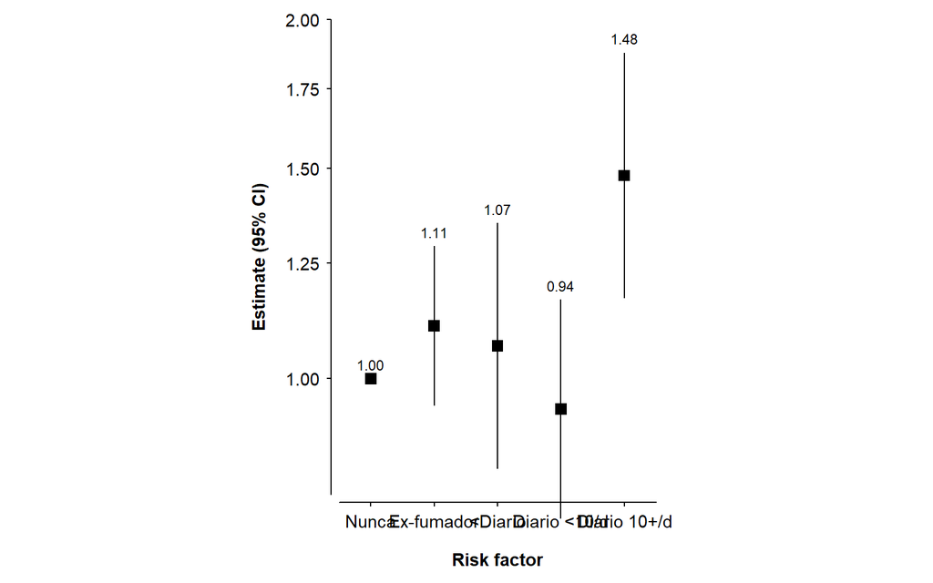

```r
ckbplotr::shape_plot(
  # Definir los datos a usar
  data = smoking_results,
  # Definir la columna con los valores para el eje x
  col.x = "smk_cat",
  # Definir los límites en el eje x.
  xlims = c(0.5,5.5),
   # Definir los límites en el eje y.
  ylims = c(0.8,2),
  # Definir la escala en el eje y
  exponentiate = TRUE)
```

Una gran cosa sobre `ckbplotr` es que junto con el gráfico, produce el código ggplot2 usado para producir el gráfico.

Para aquellos que usan ggplot2 regularmente, este es un gran punto de partida en caso de que se desee una edición muy detallada.

## Editar el gráfico según sea necesario

Nota que el intervalo de confianza del cuarto cuadrado de izquierda a derecha cruza la línea del eje x. Sería mejor si no lo hiciera, así que necesitamos expandir el rango del eje.

También sería útil agregar algunas etiquetas a los ejes.

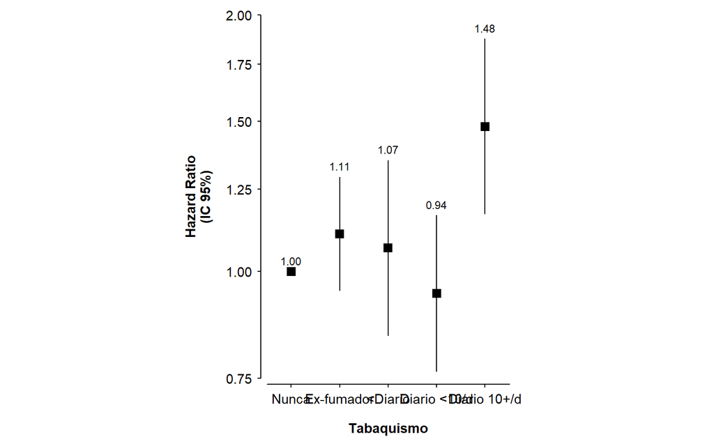

```r
ckbplotr::shape_plot(smoking_results,
                     col.x = "smk_cat",
                     xlims = c(0.5,5.5),
                     ylims = c(0.75,2),
                     exponentiate = TRUE,
                     xlab = "Tabaquismo",
                     ylab = "Hazard Ratio\n(IC 95%)")
```

Es buena práctica que el tamaño de los cuadrados refleje la cantidad de información estadística.

Configurar `scalepoints = TRUE` hace que el gráfico tenga un tamaño de punto (área) proporcional al inverso de la varianza (es decir, SE^2) de la estimación.

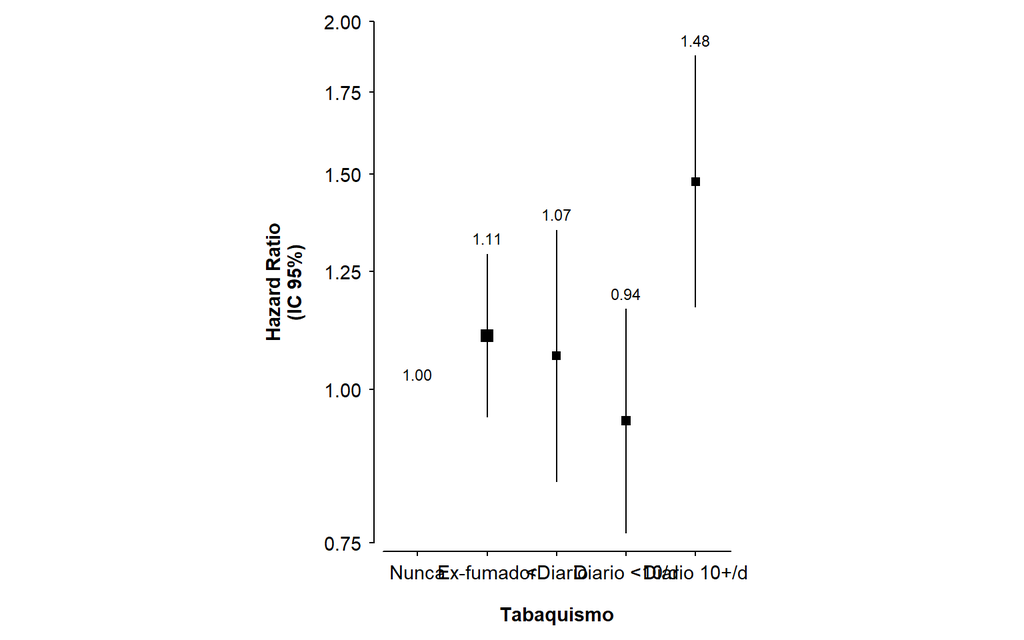

```r
ckbplotr::shape_plot(smoking_results,
                     col.x = "smk_cat",
                     xlims = c(0.5,5.5),
                     ylims = c(0.75,2),
                     exponentiate = TRUE,
                     xlab = "Tabaquismo",
                     ylab = "Hazard Ratio\n(IC 95%)",
                     scalepoints = TRUE)
```

Sin embargo, esto no funciona del todo para el grupo de referencia, ya que agregamos manualmente un error estándar de 0. Recuerda que tuvimos que hacer esto porque `coxph()` (y otros modelos lineales) no proporcionan un error estándar para el grupo de referencia.

Elegir el grupo de referencia en análisis de riesgo categórico es un problema no trivial en epidemiología y bioestadística.

En muchos casos es apropiado usar el grupo de referencia “natural” (ej. pacientes no tratados/nunca fumadores) ya que usualmente hay interés en comparaciones con este grupo.

En otros casos puede ser más apropiado usar la categoría más grande como el grupo de referencia ya que esto ayudará a minimizar la varianza de los RRs resultantes (es decir, más observaciones o más eventos en un grupo dado, menos incertidumbre estadística alrededor de las estimaciones).

Cualquier grupo que se elija, los resultados solo permitirán a los lectores comparar riesgos en cada uno de los otros grupos con este grupo de referencia.

Entonces, ¿no hay solución?

## Riesgos absolutos flotantes

**Los riesgos absolutos flotantes** (FARs por sus siglas en inglés; floating absolute risks) producen parámetros y estimaciones de varianza que se refieren a RIESGOS LOG ESPECÍFICOS DEL GRUPO en lugar de **DIFERENCIAS** ENTRE RIESGOS LOG.

El cálculo de FARs está fuera del alcance de esta práctica. Los puntos clave a entender son que los FARs:

- Nos permiten tratar log-RRs como “riesgos log específicos del grupo” (medidos desde el grupo de referencia) que son efectivamente independientes.
- Esto permite a los lectores comparar riesgos entre cualquiera de dos categorías (incluso si una no es la referencia) **Y** estimar tendencias.
- Esta forma de presentación es particularmente útil cuando no hay un grupo de referencia natural, o si el grupo de referencia natural es pequeño.
- Se pueden usar varios algoritmos para estimar las varianzas específicas del grupo (Easton et al, 1991; Plummer et al, 2004, Firth y de Menezes, 2004).
- Las estimaciones basadas en diferentes enfoques pueden variar ligeramente en ciertas circunstancias (ej. confusión sustancial) pero son generalmente similares.

**IMPORTANTE**: Al citar resultados de comparaciones específicas — se deben reportar SEs e ICs convencionales que tomen en cuenta la variación dentro de ambos grupos.

La función `float` en el paquete Epi puede ser usada para calcular varianzas flotantes (método Plummer).

```r
float <- Epi::float(smk_cox_mod)
float
```

```
## Floating treatment contrasts for factor  smokegp_cat
##
##  Level        Coefficient Std. Error 95% Floating CI
##  Nunca         0.00000    0.05474    (-0.10729, 0.10729)
##  Ex-fumador    0.10161    0.05717    (-0.01043, 0.21365)
##  <Diario       0.06333    0.10843    (-0.14918, 0.27584)
##  Diario <10/d -0.05870    0.09226    (-0.23953, 0.12212)
##  Diario 10+/d  0.39177    0.10632    ( 0.18339, 0.60015)
##
## Error limits over all contrasts:  0.97,1.03
```

Nota que solo los Errores Estándar han cambiado (incluyendo un nuevo SE para los “Nunca Fumadores”), los coeficientes son idénticos.

Estos FARs pueden ser usados para producir nuestro gráfico:

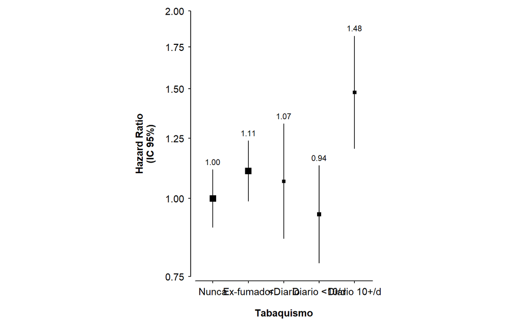

```r
smoking_results <-
  # Definir como un objeto data.frame
  data.frame(
    # Hacer los niveles del factor de riesgo como un factor
    smk_cat = factor(
      c("Nunca","Ex-fumador","<Diario","Diario <10/d","Diario 10+/d"),
      levels = c("Nunca","Ex-fumador","<Diario","Diario <10/d","Diario 10+/d")),
    # Usar los coeficientes de float
    est = float$coef,
    # El SE es igual a la raíz cuadrada de la varianza
    se = sqrt(float$var)
  )

ckbplotr::shape_plot(smoking_results,
                     col.x = "smk_cat",
                     xlims = c(0.5,5.5),
                     ylims = c(0.75,2),
                     exponentiate = TRUE,
                     xlab = "Tabaquismo",
                     ylab = "Hazard Ratio\n(IC 95%)",
                     scalepoints = TRUE)
```

Nota cómo cada uno de los cuadrados e ICs ahora reflejan la varianza dentro del logaritmo-del-riesgo en cada grupo.

## Continúa editando el gráfico según sea necesario

Hay bastantes problemas con las etiquetas para las marcas en el eje x. Para arreglar esto, se necesitará edición avanzada.

Para estas personalizaciones avanzadas, necesitamos usar ggplot2.

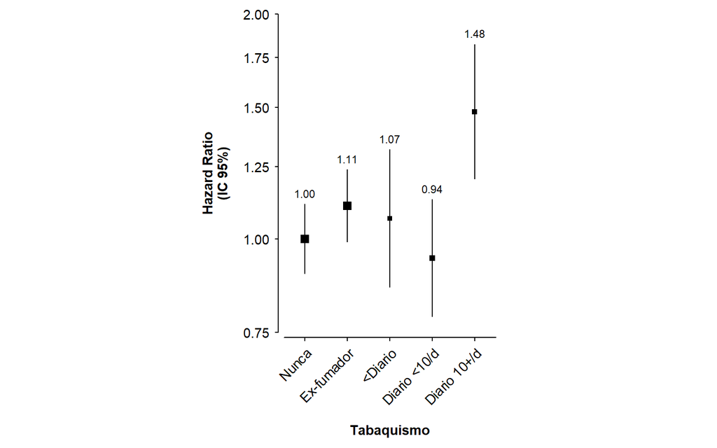

```r
my_theme <- theme(axis.text.x = element_text(angle = 45, hjust = 1))

ckbplotr::shape_plot(smoking_results,
                     col.x = "smk_cat",
                     xlims = c(0.5,5.5),
                     ylims = c(0.75,2),
                     exponentiate = TRUE,
                     xlab = "Tabaquismo",
                     ylab = "Hazard Ratio\n(IC 95%)",
                     scalepoints = TRUE,
                     add = list(end = my_theme))
```

Este gráfico es realmente informativo y casi de calidad de publicación.

# 2. Ve más allá

Esta sección del práctico aún está en desarrollo. Como tal, algunas de las respuestas a los desafíos no tendrán muchos detalles.

Sin embargo, pensamos que sería bueno compartirlo contigo.

## Desafío de gráfico de forma

### Instrucciones

Este desafío tiene como objetivo integrar lo que aprendiste en los prácticas 1 y 2.

Necesitas estimar la asociación entre el índice de masa corporal (IMC) y mortalidad por todas las causas en participantes de la cohorte similar a EPCM **SIN** diabetes. Tus análisis deben ser ajustados por sexo, estatus socioeconómico y características de estilo de vida y estratificados por edad-en-riesgo. Tus análisis deberán estar limitados sólo a muertes que occurren en las edades de 35-74 años.

La diabetes debe ser definida como aquellos con diabetes diagnosticada auto-reportada, aquellos usando medicación antidiabética, o aquellos con una hemoglobina glycosilada (HbA1c) > 7%.

### Respuesta

Hacer nuevos grupos de factores de riesgo.

```r
# Hacer agrupaciones de IMC de la OMS
dummy_df$bmi <- with(dummy_df, weight / (height / 100)^2)

dummy_df$whobmigp <- NA
dummy_df$whobmigp[dummy_df$bmi < 18.5] <- 1  # bajo peso
dummy_df$whobmigp[dummy_df$bmi >= 18.5 & dummy_df$bmi < 25] <- 2  # saludable
dummy_df$whobmigp[dummy_df$bmi >= 25 & dummy_df$bmi < 30] <- 3  # sobrepeso
dummy_df$whobmigp[dummy_df$bmi >= 30 & dummy_df$bmi < 35] <- 4  # obeso I
dummy_df$whobmigp[dummy_df$bmi >= 35 & dummy_df$bmi < 40] <- 5  # obeso II
dummy_df$whobmigp[dummy_df$bmi >= 40 & dummy_df$bmi < 60] <- 6  # obeso III

dummy_df$whobmigp_fct <- factor(dummy_df$whobmigp,
                            levels = c(1, 2, 3, 4, 5, 6),
                            labels = c("Bajo peso", "Saludable", "Sobrepeso", "Obesidad I", "Obesidad II", "Obesidad III"))

dummy_df$high_hba1c <- ifelse(dummy_df$base_hba1c > 7, 1, 0)

dummy_df$diabetes <-
  pmax(dummy_df$base_diabetes,
       dummy_df$drug_antidiabetic,
       dummy_df$high_hba1c, na.rm = TRUE)

table(dummy_df$whobmigp)
```

```
##
##    1    2    3    4    5    6
##   77 3867 8595 5302 1589  570
```

Hacer variables necesarias para la expansión de Lexis y definir la función.

Solo en aquellos sin diabetes.

```r
age_at_risk_df <- dummy_df[dummy_df$diabetes==0]

# Hacer edad calendario
age_at_risk_df$calendar_age <- age_at_risk_df$age

age_at_risk_df$study_date <- as.Date(rep("2000-01-01",dim(age_at_risk_df)[1]))

age_at_risk_df$dob <-
  age_at_risk_df$study_date - round(365.25 * age_at_risk_df$age)

age_at_risk_df$censoring_date <-
  age_at_risk_df$study_date + round(365.25 * age_at_risk_df$person_years)

age_at_risk_df$csid          <- age_at_risk_df$patid
age_at_risk_df$endpoint      <- age_at_risk_df$d000
age_at_risk_df$endpoint_date <- age_at_risk_df$censoring_date
age_at_risk_df$dob_anon      <- age_at_risk_df$dob

expand_age_at_risk <- function(df, ages) {
  df %>%

    # mantener solo las columnas necesarias, para reducir requerimientos de memoria
    select(csid, dob_anon, study_date, endpoint, endpoint_date) %>%

    # remover incompletos
    na.omit() %>%

    # crear fila para cada participante y cada grupo de edad
    crossing(tibble(XAgeGrp_start = ages[-length(ages)],
                    XAgeGrp_end = ages[-1])) %>%
    mutate(XAgeGrp = (XAgeGrp_start + XAgeGrp_end)/2) %>%

    # fecha de inicio de cada intervalo es cumpleaños (es decir, años calendario después de dob)
    mutate(start_int = add_with_rollback(as.Date(dob_anon),
                                         years(XAgeGrp_start),
                                         roll_to_first = T)) %>%

    # remover intervalos que empiezan después de la fecha de censura
    filter(start_int <= as.Date(endpoint_date)) %>%

    # fecha de fin de cada intervalo es día antes del siguiente intervalo
    mutate(end_int = add_with_rollback(as.Date(dob_anon),
                                       years(XAgeGrp_end),
                                       roll_to_first = T) - 1) %>%

    # remover intervalos que terminan antes de entrar al estudio
    filter(end_int >= as.Date(study_date)) %>%

    # corregir fecha de inicio y fin para intervalos parcialmente durante el estudio
    mutate(start_int = pmax(as.Date(study_date), start_int),
           end_int   = pmin(as.Date(endpoint_date), end_int)) %>%

    # endpoint solo puede ser 1 para el último intervalo
    mutate(endpoint = as.numeric(end_int == as.Date(endpoint_date) & endpoint),

           # calcular días / años desde el inicio del estudio
           ## terminar intervalos en + 0.95 como en 'sistema Cox de SAS'
           t_start_days   = interval(as.Date(study_date), start_int) / days(1),
           t_end_days     = interval(as.Date(study_date), end_int) / days(1) + 0.95,
           time_in        = t_start_days / 365.25,
           time_out       = t_end_days / 365.25)
}
```

Hacer expansión de bandas de edad-en-riesgo (muertes a edades 35-74 años).

```r
dataset_long <-
  expand_age_at_risk(df = age_at_risk_df,
                     ages = c(35, 40, 45, 50, 55, 60, 65, 70, 75))

dataset_long <-
  merge(dataset_long,
        age_at_risk_df
        [, c("csid", "new_diabetes", "coyoacan", "male", "edu_level_cat",
             "smokegp_cat", "alcgp_cat","physgp_cat","whobmigp","whobmigp_fct")])
```

Ejecutar modelo Cox PH.

```r
bmi_cox_mod<-
  # Ajustar los modelos de regresión cox, con tiempos de inicio y fin
  coxph(Surv(time_in, time_out, endpoint) ~
          # Factor de riesgo de interés
          relevel(factor(dataset_long$whobmigp), ref = 2) +
          # Otras covariables de interés
          coyoacan + male +  edu_level_cat + smokegp_cat + alcgp_cat + physgp_cat +
          # Estratos
          strata(as.factor(XAgeGrp)),
             data = dataset_long)
summary(bmi_cox_mod)
```

```
## Call:
## coxph(formula = Surv(time_in, time_out, endpoint) ~ relevel(factor(dataset_long$whobmigp),
##     ref = 2) + coyoacan + male + edu_level_cat + smokegp_cat +
##     alcgp_cat + physgp_cat + strata(as.factor(XAgeGrp)), data = dataset_long)
##
##   n= 69006, number of events= 1144
##
##                                                       coef exp(coef)  se(coef)
## relevel(factor(dataset_long$whobmigp), ref = 2)1  0.454218  1.574941  0.415260
## relevel(factor(dataset_long$whobmigp), ref = 2)3 -0.194886  0.822929  0.085071
## relevel(factor(dataset_long$whobmigp), ref = 2)4  0.075454  1.078374  0.089808
## relevel(factor(dataset_long$whobmigp), ref = 2)5  0.359224  1.432218  0.116772
## relevel(factor(dataset_long$whobmigp), ref = 2)6  0.916096  2.499513  0.141408
## coyoacan                                         -0.372130  0.689265  0.065603
## male                                              0.656892  1.928788  0.071937
## edu_level_catPreparatoria                         0.357928  1.430363  0.105519
## edu_level_catPrimaria                             0.430748  1.538408  0.101521
## edu_level_catOtro                                 0.467339  1.595742  0.135109
## smokegp_catEx-fumador                            -0.066497  0.935665  0.090511
## smokegp_cat<Diario                                0.100354  1.105562  0.102321
## smokegp_catDiario <10/d                           0.189720  1.208911  0.091968
## smokegp_catDiario 10+/d                           0.485226  1.624541  0.106164
## alcgp_catEx-bebedor                              -0.016630  0.983507  0.108551
## alcgp_catHasta 3 veces/mes                       -0.230900  0.793819  0.084306
## alcgp_catHasta 2 veces/sem                       -0.066074  0.936061  0.142165
## alcgp_cat3+ veces/sem                             0.168725  1.183795  0.188339
## physgp_catHasta 2 veces/sem                      -0.215591  0.806065  0.115870
## physgp_cat3+ veces/sem                            0.006638  1.006660  0.089712
##                                                       z Pr(>|z|)
## relevel(factor(dataset_long$whobmigp), ref = 2)1  1.094 0.274037
## relevel(factor(dataset_long$whobmigp), ref = 2)3 -2.291 0.021971 *
## relevel(factor(dataset_long$whobmigp), ref = 2)4  0.840 0.400812
## relevel(factor(dataset_long$whobmigp), ref = 2)5  3.076 0.002096 **
## relevel(factor(dataset_long$whobmigp), ref = 2)6  6.478 9.27e-11 ***
## coyoacan                                         -5.672 1.41e-08 ***
## male                                              9.132  < 2e-16 ***
## edu_level_catPreparatoria                         3.392 0.000694 ***
## edu_level_catPrimaria                             4.243 2.21e-05 ***
## edu_level_catOtro                                 3.459 0.000542 ***
## smokegp_catEx-fumador                            -0.735 0.462531
```

[output cut: 44 more lines]

```
## smokegp_catEx-fumador                               1.1173
## smokegp_cat<Diario                                  1.3511
## smokegp_catDiario <10/d                             1.4477
## smokegp_catDiario 10+/d                             2.0003
## alcgp_catEx-bebedor                                 1.2167
## alcgp_catHasta 3 veces/mes                          0.9364
## alcgp_catHasta 2 veces/sem                          1.2368
## alcgp_cat3+ veces/sem                               1.7123
## physgp_catHasta 2 veces/sem                         1.0116
## physgp_cat3+ veces/sem                              1.2002
##
## Concordance= 0.643  (se = 0.009 )
## Likelihood ratio test= 282.9  on 20 df,   p=<2e-16
## Wald test            = 293.8  on 20 df,   p=<2e-16
## Score (logrank) test = 303.5  on 20 df,   p=<2e-16
```

Calcular FARs

```r
float <- Epi::float(bmi_cox_mod)
float
```

```
## Floating treatment contrasts for factor  relevel(factor(dataset_long$whobmigp), ref = 2)
##
##  Level Coefficient Std. Error 95% Floating CI
##  2      0.00000    0.07009    (-0.13738, 0.13738)
##  1      0.45422    0.40989    (-0.34915, 1.25758)
##  3     -0.19489    0.04977    (-0.29244,-0.09734)
##  4      0.07545    0.05565    (-0.03363, 0.18454)
##  5      0.35922    0.09224    ( 0.17845, 0.54000)
##  6      0.91610    0.12149    ( 0.67797, 1.15422)
##
## Error limits over all contrasts:  0.97,1.01
```

Hacer data frame con números necesarios

```r
bmi_results <-
  # Definir como un objeto data.frame
  data.frame(
    # Hacer los niveles del factor de riesgo como un factor
    bmi_cat = as.numeric(names(float$coef)),
    # Usar los coeficientes de float
    est = float$coef,
    # El SE es igual a la raíz cuadrada de la varianza
    se = sqrt(float$var)
  )

bmi_results <- bmi_results[order(bmi_results$bmi_cat, decreasing = FALSE), ]
# Calcular IMC promedio en cada nivel de whobmicat
mean_by_bmicat <-
  tapply(age_at_risk_df$bmi, age_at_risk_df$whobmigp, mean) %>%
  as.data.frame()
names(mean_by_bmicat) <- "mean"
mean_by_bmicat$bmi_cat <- row.names(mean_by_bmicat)

bmi_results <- merge(bmi_results,mean_by_bmicat)
```

Hacer gráfico.

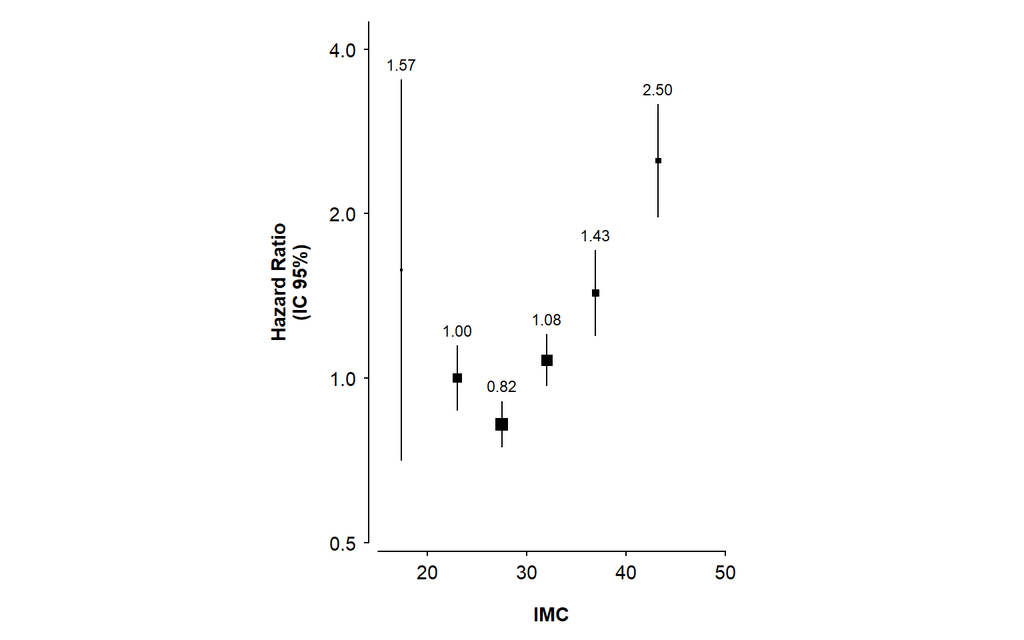

```r
ckbplotr::shape_plot(bmi_results,
                     col.x = "mean",
                     xlims = c(15,50),
                     ylims = c(0.5,4.5),
                     ybreaks = c(0.5,1.0,2.0,4.0),
                     exponentiate = TRUE,
                     xlab = "IMC",
                     ylab = "Hazard Ratio\n(IC 95%)",
                     scalepoints = TRUE)
```

Tómate tu tiempo para inspeccionar este gráfico y considerar los puntos buenos (y los malos).

Incluso con una muestra inicial de 20,000 participantes, parece que realmente no tenemos suficiente poder para evaluar la asociación de IMC y mortalidad por debajo del rango de IMC de 20 kg/m^2.

## Construcción de tablas de resultados

Construir y exportar tablas de resultados cuando se hacen análisis con R sigue los siguientes pasos básicos:

1. Hacer el análisis
2. Extraer números de interés de por ejemplo un objeto de modelo ajustado
3. Calcular números adicionales
4. Formatear números
5. Construir un data frame
6. Hacer del data frame una tabla
7. Mostrar la tabla en un archivo

En la práctica, los pasos de abajo pueden ser codificados más concisamente y puedes refinar tu propio código para tus necesidades y flujo de trabajo.

## Análisis de ejemplo

Empecemos usando `glm()` para ajustar un modelo simple de regresión logística para usar como ejemplo.

```r
model <- glm(formula = am ~ cyl + hp + wt, family = binomial, data = mtcars)
```

## Extraer números de interés

```r
model_summary <- summary(model)
coefs <- model_summary$coefficients[2:4,]
coefs <- as.data.frame(coefs)
```

Agregar una nueva columna con nombres para cada fila:

```r
coefs$name <- c("Numero de cilindros", "Caballos de fuerza brutos", "Peso (1000lbs)")
coefs
```

```
##        Estimate Std. Error    z value   Pr(>|z|)                      name
## cyl  0.48759798 1.07162064  0.4550099 0.64910213       Numero de cilindros
## hp   0.03259168 0.01886105  1.7279882 0.08399033 Caballos de fuerza brutos
## wt  -9.14947127 4.15332368 -2.2029276 0.02759985            Peso (1000lbs)
```

## Calcular otros números

Calcular nuevas columnas de odds ratios y los límites de intervalos de confianza del 95%.

```r
coefs$OR <- exp(coefs$Estimate)
coefs$L_OR <- exp(coefs$Estimate - 1.96 * coefs$`Std. Error`)
coefs$U_OR <- exp(coefs$Estimate + 1.96 * coefs$`Std. Error`)
coefs
```

```
##        Estimate Std. Error    z value   Pr(>|z|)                      name
## cyl  0.48759798 1.07162064  0.4550099 0.64910213       Numero de cilindros
## hp   0.03259168 0.01886105  1.7279882 0.08399033 Caballos de fuerza brutos
## wt  -9.14947127 4.15332368 -2.2029276 0.02759985            Peso (1000lbs)
##              OR         L_OR       U_OR
## cyl 1.628400061 1.993330e-01 13.3027986
## hp  1.033128602 9.956336e-01  1.0720357
## wt  0.000106276 3.097809e-08  0.3645991
```

## Formatear números

Usualmente queremos presentar números redondeados y en un formato bonito. Los paquetes para crear tablas (como `kable` discutido abajo) pueden hacer esto, pero también puedes hacerlo tú mismo con funciones como `round`, `format`, y `paste`.

Usa `round` para redondear los ORs a 2 lugares decimales:

```r
coefs$OR <- round(coefs$OR, 2)
coefs
```

```
##        Estimate Std. Error    z value   Pr(>|z|)                      name   OR
## cyl  0.48759798 1.07162064  0.4550099 0.64910213       Numero de cilindros 1.63
## hp   0.03259168 0.01886105  1.7279882 0.08399033 Caballos de fuerza brutos 1.03
## wt  -9.14947127 4.15332368 -2.2029276 0.02759985            Peso (1000lbs) 0.00
##             L_OR       U_OR
## cyl 1.993330e-01 13.3027986
## hp  9.956336e-01  1.0720357
## wt  3.097809e-08  0.3645991
```

Usa `format` para convertir números en texto. Configuraremos `nsmall` para que los números siempre se impriman con dos dígitos a la derecha del punto decimal (coincidiendo con el redondeo). También configuraremos `trim = TRUE` para remover espacios en blanco al inicio.

```r
coefs$OR <- format(coefs$OR, nsmall = 2, trim = TRUE)
coefs
```

```
##        Estimate Std. Error    z value   Pr(>|z|)                      name   OR
## cyl  0.48759798 1.07162064  0.4550099 0.64910213       Numero de cilindros 1.63
## hp   0.03259168 0.01886105  1.7279882 0.08399033 Caballos de fuerza brutos 1.03
## wt  -9.14947127 4.15332368 -2.2029276 0.02759985            Peso (1000lbs) 0.00
##             L_OR       U_OR
## cyl 1.993330e-01 13.3027986
## hp  9.956336e-01  1.0720357
## wt  3.097809e-08  0.3645991
```

Para los límites del intervalo de confianza, haremos ambos pasos en uno:

```r
coefs$L_OR <- format(round(coefs$L_OR, 2), nsmall = 2, trim = TRUE)
coefs$U_OR <- format(round(coefs$U_OR, 2), nsmall = 2, trim = TRUE)
coefs
```

```
##        Estimate Std. Error    z value   Pr(>|z|)                      name   OR
## cyl  0.48759798 1.07162064  0.4550099 0.64910213       Numero de cilindros 1.63
## hp   0.03259168 0.01886105  1.7279882 0.08399033 Caballos de fuerza brutos 1.03
## wt  -9.14947127 4.15332368 -2.2029276 0.02759985            Peso (1000lbs) 0.00
##     L_OR  U_OR
## cyl 0.20 13.30
## hp  1.00  1.07
## wt  0.00  0.36
```

Ahora podemos usar `paste` para juntar los ORs y límites de confianza:

```r
coefs$OR_CI <- paste(coefs$OR, " (", coefs$L_OR, ", ", coefs$U_OR, ")", sep = "")
coefs
```

```
##        Estimate Std. Error    z value   Pr(>|z|)                      name   OR
## cyl  0.48759798 1.07162064  0.4550099 0.64910213       Numero de cilindros 1.63
## hp   0.03259168 0.01886105  1.7279882 0.08399033 Caballos de fuerza brutos 1.03
## wt  -9.14947127 4.15332368 -2.2029276 0.02759985            Peso (1000lbs) 0.00
##     L_OR  U_OR              OR_CI
## cyl 0.20 13.30 1.63 (0.20, 13.30)
## hp  1.00  1.07  1.03 (1.00, 1.07)
## wt  0.00  0.36  0.00 (0.00, 0.36)
```

Nota que `paste0` es equivalente a `paste(..., sep = "")`.

Sigamos los mismos pasos para los valores de p. Vamos a usar la función `ifelse` para presentar valores pequeños como “<0.01”.

```r
coefs$p <- ifelse(coefs$`Pr(>|z|)` < 0.01, "<0.01", format(round(coefs$`Pr(>|z|)`, 2), nsmall = 2))
coefs
```

```
##        Estimate Std. Error    z value   Pr(>|z|)                      name   OR
## cyl  0.48759798 1.07162064  0.4550099 0.64910213       Numero de cilindros 1.63
## hp   0.03259168 0.01886105  1.7279882 0.08399033 Caballos de fuerza brutos 1.03
## wt  -9.14947127 4.15332368 -2.2029276 0.02759985            Peso (1000lbs) 0.00
##     L_OR  U_OR              OR_CI    p
## cyl 0.20 13.30 1.63 (0.20, 13.30) 0.65
## hp  1.00  1.07  1.03 (1.00, 1.07) 0.08
## wt  0.00  0.36  0.00 (0.00, 0.36) 0.03
```

## Construir un data frame

Para preparar una tabla, podemos seleccionar un subconjunto de filas y columnas del data frame coefs.

```r
table <- coefs[1:2, c("name", "OR_CI", "p")]
table
```

```
##                          name              OR_CI    p
## cyl       Numero de cilindros 1.63 (0.20, 13.30) 0.65
## hp  Caballos de fuerza brutos  1.03 (1.00, 1.07) 0.08
```

## Hacer una tabla

Varios paquetes de R están disponibles para crear una tabla formateada adecuada para presentación a partir de un data frame.

El paquete `flextable` es particularmente útil para crear tablas que se mostrarán en documentos de Word.

```r
pacman::p_load(flextable,officer)
# Crear un objeto flextable del data frame
ft <- flextable(table)

# Guardar la flextable como un documento de Word
doc <- read_docx() %>%
  body_add_flextable(ft) %>%
  print(target = "flextable_table.docx")
```

Ver la documentación para flextable [aquí](https://www.rdocumentation.org/packages/flextable/versions/0.9.5).

## Generar un archivo con R Markdown

Después de construir y crear una tabla en R, querremos presentar la tabla en un documento. R Markdown puede ser usado para esto.

Markdown es un lenguaje de marcado que te permite agregar formato simple a un archivo de texto plano. R Markdown te permite insertar chunks de código R también, que serán ejecutados cuando conviertas el archivo a un documento PDF, HTML o Word. Puedes aprender sobre R markdown desde RStudio en https://rmarkdown.rstudio.com. Un libro de referencia extensivo es [R Markdown: The Definitive Guide](https://bookdown.org/yihui/rmarkdown/).

Puedes incluir el código para análisis y crear tablas en un documento de R Markdown. El código R se incluye poniéndolo entre delimitadores de chunk `` ```{r} `` y `` ``` ``. Las opciones de chunk te permiten elegir cuándo el código y/o la salida se muestra en el documento final.

Convierte el archivo R Markdown a un documento PDF, HTML, o Word abriéndolo con RStudio y haciendo clic en el botón Knit (usa la flecha desplegable para seleccionar el tipo de archivo). O usa la función `render` del paquete rmarkdown.

Si quieres tener tu código de análisis separado, puedes guardar tu tabla en un archivo…

```r
saveRDS(my_table, file = "my_table.rds")
```

…y luego leerlo en el documento R Markdown:

```r
readRDS("my_table.rds")
```

Si debes generar un documento de Word, entonces usar un “documento de referencia de estilo” es muy útil (ver https://bookdown.org/yihui/rmarkdown/word-document.html).

Regresar a la Tabla de Contenido.